# Dane powtarzane w czasie (longitudinal studies - random coefficients)

Przemyslaw Biecek

Modele liniowe

# 1 Model z losowymi współczynnikami

## 1.1 Zbiór danych `kidney`

Zmienna MDRD to ocena sprawności nerki, czyli tzw. Glomerular Filtration Rate (GFR). Ta wartość jest używana do oceny czy nerka wciąż sprawnie filtruje krew. Interpretacja jest taka, że im wyższa wartość MDRD tym lepiej.

W zbiorze danych `kidney` mamy profile zmian w MDRD dla pacjentów po transplantacji nerki. Pomiary zaczynają się 7 dni po przeszczepie, są prowadzone w nieregularnych chwilach, ostatni pomiar mamy w 60 miesiącu po przeszczepie (o ile pacjent dożył tego czasu).

```r
library(lme4)
library(PBImisc)
head(kidney)
```

```
##   recipient.age donor.age CIT discrepancy.AB discrepancy.DR therapy
## 1            26        40  25              2              1      tc
## 2            52        62  31              4              1      cm
## 3            50        50  20              2              1      cm
## 4            56        47  38              3              0      tc
## 5            67        18  26              1              1      ca
## 6            26        45  22              1              0      cm
##   diabetes bpl.drugs MDRD7 MDRD30 MDRD3 MDRD6 MDRD12 MDRD24 MDRD36 MDRD60
## 1        0         3    46     71  65.0    71     65     70     76     72
## 2        1         4    44     58  20.0    78     62     87     72     47
## 3        0         2     6     36  37.8    42     45     46     46     33
## 4        0         3     8     39  55.7    52     60     73     75     91
## 5        0         1    36     79  64.2    64     64     79     70     63
## 6        0         3     9     43  58.0    49     45     51     48     56
```

Do dalszych analiz potrzebujemy przekształcić dane do tzw. długiego formatu (też nazywanego RCV row-column-value).

```r
lkidney = reshape(kidney, direction="long", varying=list(9:16), v.names=c("MDRD"), times=c(1/4,1,3,6,12,24,36,60))
head(lkidney[,5:11])
```

```
##        discrepancy.DR therapy diabetes bpl.drugs time MDRD id
## 1.0.25              1      tc        0         3 0.25   46  1
## 2.0.25              1      cm        1         4 0.25   44  2
## 3.0.25              1      cm        0         2 0.25    6  3
## 4.0.25              0      tc        0         3 0.25    8  4
## 5.0.25              1      ca        0         1 0.25   36  5
## 6.0.25              0      cm        0         3 0.25    9  6
```

Ponieważ punkty czasowe są nierównomiernie rozłożone, dobrym pomysłem jest użycie `log(time)` zamiast `time`.

```r
lkidney$ltime = log(lkidney$time)
lkidney$title = factor(with(lkidney, paste("wiek ", recipient.age,"/",donor.age, ", zgod. ", discrepancy.AB,"/",discrepancy.DR, sep="")))
```

## 1.2 Wykresy

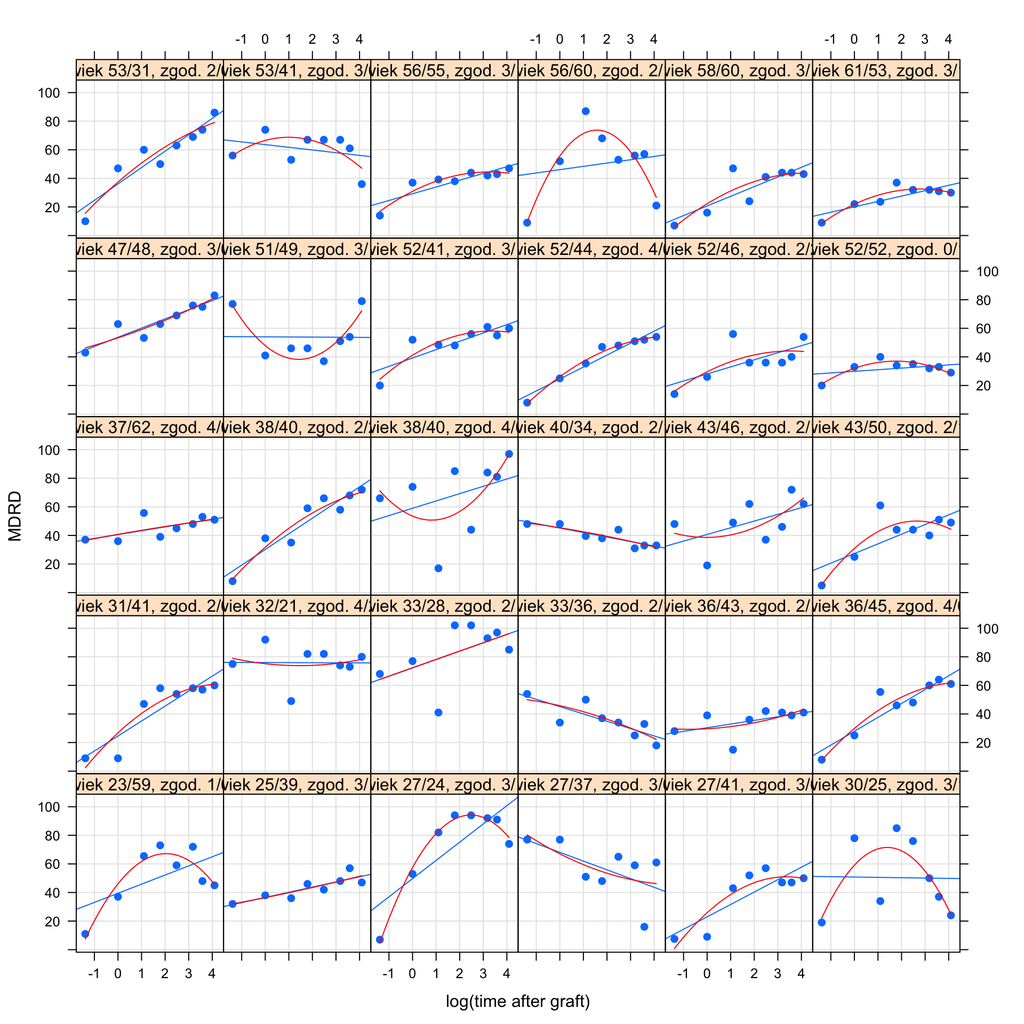

```r
library(lattice)
# panel for lattice package
panel.with.square <- function(...){
  nx = list(...)$x
  ny = list(...)$y
  cc = lm(ny~nx+I(nx^2))$coef
  panel.xyplot(...)
  panel.curve(x^2*cc[3]+x*cc[2]+cc[1], from=min(nx), to=max(nx), col="red")
}
# the plot
xyplot(MDRD ~ log(time) | title, lkidney, type = c("g","p","r"),
  xlab = "log(time after graft)", ylab = "MDRD", pch=19,
  panel = panel.with.square, subset= id>20 & id < 51)
```

## 1.3 Modele

Teraz możemy rozpocząć modelowanie.

Porównajmy trzy modele, tylko z wyrazem wolnym, nachyleniem i jednym i drugim.

```r
(model0 = lmer(MDRD~1 + (1|id), data=lkidney, REML=FALSE))
```

```
## Linear mixed model fit by maximum likelihood  ['lmerMod']
## Formula: MDRD ~ 1 + (1 | id)
##    Data: lkidney
##       AIC       BIC    logLik  deviance  df.resid
##  23221.99  23239.66 -11607.99  23215.99      2669
## Random effects:
##  Groups   Name        Std.Dev.
##  id       (Intercept) 11.48
##  Residual             16.93
## Number of obs: 2672, groups:  id, 334
## Fixed Effects:
## (Intercept)
##       48.48
```

```r
(model1 = lmer(MDRD~ltime + (ltime|id), data=lkidney, REML=FALSE))
```

```
## Linear mixed model fit by maximum likelihood  ['lmerMod']
## Formula: MDRD ~ ltime + (ltime | id)
##    Data: lkidney
##       AIC       BIC    logLik  deviance  df.resid
##  22445.15  22480.49 -11216.57  22433.15      2666
## Random effects:
##  Groups   Name        Std.Dev. Corr
##  id       (Intercept) 11.624
##           ltime        2.894   -0.16
##  Residual             13.611
## Number of obs: 2672, groups:  id, 334
## Fixed Effects:
## (Intercept)        ltime
##      40.108        4.512
```

```r
(model1bis = lmer(MDRD~ltime + (ltime-1|id) + (1|id), data=lkidney))
```

```
## Linear mixed model fit by REML ['lmerMod']
## Formula: MDRD ~ ltime + (ltime - 1 | id) + (1 | id)
##    Data: lkidney
## REML criterion at convergence: 22436.32
## Random effects:
##  Groups   Name        Std.Dev.
##  id       ltime        2.754
##  id.1     (Intercept) 11.237
##  Residual             13.669
## Number of obs: 2672, groups:  id, 334
## Fixed Effects:
## (Intercept)        ltime
##      40.108        4.512
```

Jak wyłuskać współczynniki dla poszczególnych pacjentów?

```r
fixef(model1)
```

```
## (Intercept)       ltime
##   40.108126    4.511859
```

```r
head(ranef(model1)$id)
```

```
##   (Intercept)       ltime
## 1  15.5033706  0.14873512
## 2   7.9479284  0.34349035
## 3 -10.0745012 -0.08182726
## 4  -0.7259554  4.62147070
## 5  13.8444530  0.07262857
## 6  -4.1490124  0.64730594
```

```r
randomCoefs = t(t(ranef(model1)$id) + fixef(model1))
head(randomCoefs)
```

```
##   (Intercept)    ltime
## 1    55.61150 4.660595
## 2    48.05605 4.855350
## 3    30.03362 4.430032
## 4    39.38217 9.133330
## 5    53.95258 4.584488
## 6    35.95911 5.159165
```

## 1.4 Modele z efektami stałymi

Dla każdego pacjenta, moglibyśmy wyznaczyć model liniowy tylko z efektami stałymi.

Zobaczmy jak wygląda porównanie obu podejść do modelowania.

```r
model1fixed = lm(MDRD~ltime:factor(id) + factor(id) - 1, data=lkidney)
fixedCoefs = matrix(coef(model1fixed), ncol=2)
head(fixedCoefs)
```

```
##          [,1]      [,2]
## [1,] 60.12820  3.703253
## [2,] 49.97823  4.592431
## [3,] 27.07673  5.064779
## [4,] 32.35810 13.124720
## [5,] 58.07457  3.678262
## [6,] 33.73900  6.001253
```

```r
lmList(MDRD ~ time | id, lkidney)
## Call: lmList(formula = MDRD ~ time | id, data = lkidney)
## Coefficients:
##     (Intercept)         time
## 1      63.09062  0.219859695
## 2      55.55200  0.165792565
## 3      33.66915  0.157798211
## 4      39.20332  0.984699102
## 5      62.64902  0.126592898
## 6      39.30236  0.313399820
## 7      40.23394  0.113381365
## 8      61.81949  0.298376739
## 9      49.41234  0.750096638
## 10     32.69759  0.216655569
```

## 1.5 Efekt regularyzacji

Porównajmy teraz współczynniki wyznaczone obiema metodami na jednym wykresie.

Co się dzieje ze współczynnikami?

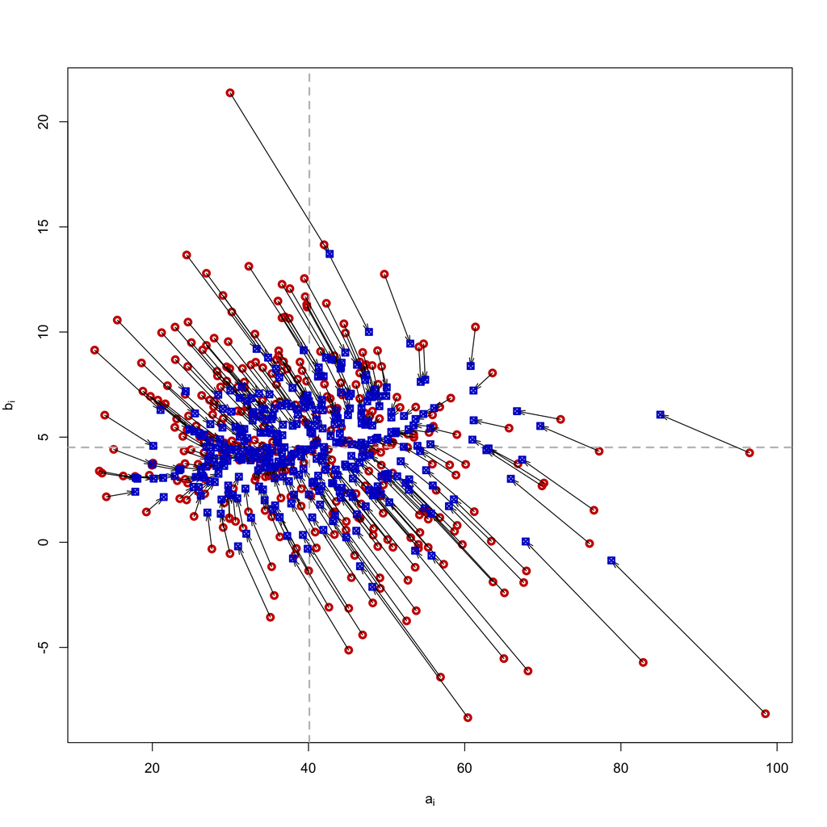

```r
plot(fixedCoefs[,1], fixedCoefs[,2], cex=1, pch=21, lwd=3, col="red3", xlab=expression(a[i]), ylab=expression(b[i]))

abline(v=fixef(model1)[1], col="grey", lwd=2, lty=2)
abline(h=fixef(model1)[2], col="grey", lwd=2, lty=2)
arrows(fixedCoefs[,1], fixedCoefs[,2], randomCoefs[,1], randomCoefs[,2], angle=15, length=0.1, lwd=1)
points(randomCoefs[,1], randomCoefs[,2], cex=1, pch=7, lwd=2, col="blue3")
```

## 1.6 Wielomiany wyższych stopni

```r
(model2 = lmer(MDRD~ltime + I(ltime^2) + (ltime+I(ltime^2)|id), data= lkidney, REML=FALSE))
```

```
## Linear mixed model fit by maximum likelihood  ['lmerMod']
## Formula: MDRD ~ ltime + I(ltime^2) + (ltime + I(ltime^2) | id)
##    Data: lkidney
##       AIC       BIC    logLik  deviance  df.resid
##  22059.43  22118.33 -11019.71  22039.43      2662
## Random effects:
##  Groups   Name        Std.Dev. Corr
##  id       (Intercept) 12.534
##           ltime        5.362    0.06
##           I(ltime^2)   1.547   -0.25 -0.80
##  Residual             11.581
## Number of obs: 2672, groups:  id, 334
## Fixed Effects:
## (Intercept)        ltime   I(ltime^2)
##      42.103        8.868       -1.544
```

```r
anova(model2,model1,model0)
```

```
## Data: lkidney
## Models:
## model0: MDRD ~ 1 + (1 | id)
## model1: MDRD ~ ltime + (ltime | id)
## model2: MDRD ~ ltime + I(ltime^2) + (ltime + I(ltime^2) | id)
##        Df   AIC   BIC logLik deviance  Chisq Chi Df Pr(>Chisq)
## model0  3 23222 23240 -11608    23216
## model1  6 22445 22480 -11217    22433 782.84      3  < 2.2e-16 ***
## model2 10 22059 22118 -11020    22039 393.72      4  < 2.2e-16 ***
## ---
## Signif. codes:  0 '***' 0.001 '**' 0.01 '*' 0.05 '.' 0.1 ' ' 1
```

## 1.7 Inne efekty stałe

Mamy już zmienne definiującą strukturę zależności, możemy przyjrzeć się jeszcze raz innym efektom stałym.

```r
(fullModel = lmer(MDRD~donor.age+ recipient.age+ therapy+ diabetes+ bpl.drugs+ discrepancy.AB+ discrepancy.DR + ltime + I(ltime^2) + (ltime + I(ltime^2)|id), data=lkidney, REML=FALSE))
```

```
## Linear mixed model fit by maximum likelihood  ['lmerMod']
## Formula:
## MDRD ~ donor.age + recipient.age + therapy + diabetes + bpl.drugs +
##     discrepancy.AB + discrepancy.DR + ltime + I(ltime^2) + (ltime +
##     I(ltime^2) | id)
##    Data: lkidney
##       AIC       BIC    logLik  deviance  df.resid
##  21983.13  22089.16 -10973.57  21947.13      2654
## Random effects:
##  Groups   Name        Std.Dev. Corr
##  id       (Intercept) 11.243
##           ltime        5.362   -0.01
##           I(ltime^2)   1.547   -0.25 -0.80
##  Residual             11.581
## Number of obs: 2672, groups:  id, 334
## Fixed Effects:
##    (Intercept)       donor.age   recipient.age       therapycm
##        68.8070         -0.3016         -0.1441         -1.4161
##      therapytc        diabetes       bpl.drugs  discrepancy.AB
##        -4.7564          2.7610         -2.1493         -0.7937
## discrepancy.DR           ltime      I(ltime^2)
##        -0.3810          8.8684         -1.5441
```

```r
(finalModel = lmer(MDRD~donor.age+ bpl.drugs+ ltime + I(ltime^2) + (ltime+I(ltime^2)|id), data=lkidney, REML=FALSE))
```

```
## Linear mixed model fit by maximum likelihood  ['lmerMod']
## Formula: MDRD ~ donor.age + bpl.drugs + ltime + I(ltime^2) + (ltime +
##     I(ltime^2) | id)
##    Data: lkidney
##       AIC       BIC    logLik  deviance  df.resid
##  21988.09  22058.78 -10982.05  21964.09      2660
## Random effects:
##  Groups   Name        Std.Dev. Corr
##  id       (Intercept) 11.561
##           ltime        5.362    0.04
##           I(ltime^2)   1.547   -0.29 -0.80
##  Residual             11.581
## Number of obs: 2672, groups:  id, 334
## Fixed Effects:
## (Intercept)    donor.age    bpl.drugs        ltime   I(ltime^2)
##     62.4087      -0.3613      -2.2960       8.8684      -1.5441
```